# Lecture 2: Understanding Data

Nick Huntington-Klein

December 1, 2018

## What’s the Point?

What are we actually trying to DO when we use data?

Contrary to popular opinion, the point isn’t to make pretty graphs or to make a point, or justify something you’ve done.

Those may be nice side effects!

## Uncovering Truths

The cleanest way to think about data analysis is to remember that data *comes from somewhere*

There was some process that *generated that data*

Our goal, in all data analysis, is to get some idea of *what that process is*

## Example

- Imagine a basic coin flip
- Every time we flip, we get heads half the time and tails half the time
- The TRUE process that generates the data is that there’s a coin that’s heads half the time and tails half the time
- If we analyze the data correctly, we should report back that the coin is heads half the time
- Let’s try calculating the *proportion* of heads

## Example

```r
#Generate 500 heads and tails
data <- sample(c("Heads","Tails"),500,replace=TRUE)
#Calculate the proportion of heads
mean(data=="Heads")
```

```
## [1] 0.49
```

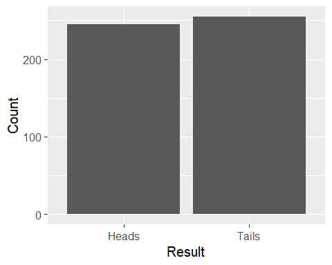

## Example

- Let’s try out that code in R a few times and see what happens
- First, what do we *want* to happen? What should we see if our data analysis method is good?

## How Good Was It?

- Our data analysis consistently told us that the coin was generating heads about half the time - the true process!
- Our data analysis lets us conclude the coin is fair
- That is describing the true data generating process pretty well!
- Let’s think - what other approaches could we have taken? What would the pros and cons be?
  - Counting the heads instead of taking the proportion?
  - Taking the mean and adding .1?
  - Just saying it’s 50%?

## Another Example

- People have different amounts of money in their wallet, from 0 to 10
- We flip a coin and, if it’s heads, give them a dollar
- What’s the data generating process here?
- What should our data analysis uncover?

## Another Example

```r
#Generate 1000 wallets and 1000 heads and tails
data <- data.frame(wallets=sample(0:10,1000,replace=TRUE))
data$coin <- sample(c("Heads","Tails"),1000,replace=TRUE)
#Give a dollar whenever it's a heads, then get average money by coin
data <- data %>% mutate(wallets = wallets + (coin=="Heads"))
data %>% group_by(coin) %>% summarize(wallets = mean(wallets))
```

```
## # A tibble: 2 x 2
##   coin  wallets
##   <chr>   <dbl>
## 1 Heads    6.02
## 2 Tails    4.97
```

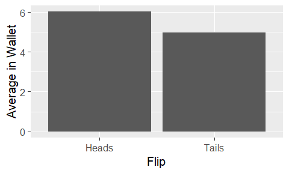

## Conclusions

- What does our data analysis tell us?
- We *observe* a difference of 1.06 between the heads and tails
- Because we know that nothing would have caused this difference other than the coin flip, we can conclude that the coin flip *is why* there’s a difference of 1.06

## But What If?

- So far we’ve been cheating
- We know exactly what process generated that data
- So really, our data analysis doesn’t matter
- But what if we *don’t* know that?
- We want to make sure our *method* is good, so that when we draw a conclusion from our data, it’s the right one

## Example 3

- We’re economists! So no big surprise we might be interested in demand curves
- Demand curve says that as $P$ goes up, $Q_d$ goes down
- Let’s gather data on $P$ and $Q_d$
- And determine things like the slope of demand, demand elasticity, etc.
- Just so happens I have some data on 1879-1923 US food export prices and quantities!

## Example 3

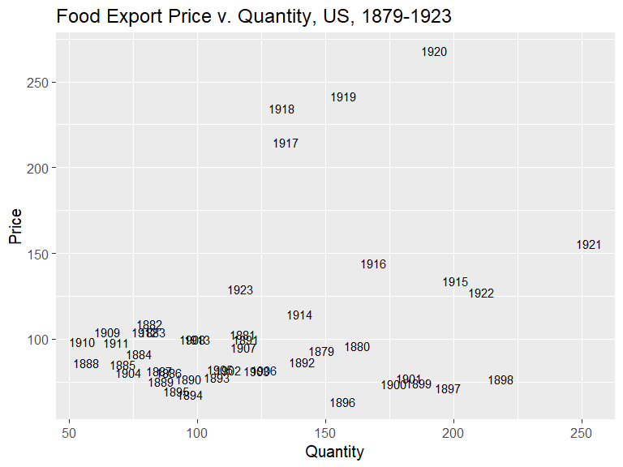

## Example 3

We can calculate the correlation between $P$ and $Q$:

```r
cor(foodPQ$FoodPrice,foodPQ$FoodQuantity)
```

```
## [1] 0.2970008
```

## Example 3 Conclusions

- We *observe* a POSITIVE correlation of 0.3
- But demand curves shouldn’t slope upwards… huh?
- Does demand really slope up? Does this tell us about the process that generated this data? Why or why not?
- Why do we see the data we do? Let’s try to think of some reasons.

## Getting Difficult

- We need to be more careful to figure out what’s actually going on
- Plus, the more we know about the context and the underlying model, the more likely it is that we won’t miss something important

## Getting Difficult

- Our fake examples were easy because we knew perfectly where the data came from
- But how much do you know about food prices in turn-of-the-century US?
- Or for that matter how prices are set in the food industry?
- There’s more work to do in uncovering the process that made the data

## For the Record

- Likely, one of the big problems with our food analysis was that we forgot to account for DEMAND shifting around, showing us what SUPPLY looks like. Supply *does* slope up!
- Just because we loudly announced that we wanted the demand curve doesn’t force the data to give it to us!
- Let’s imagine the process that might have generated this data by starting with the model itself and seeing how we can *generate* this data

## But…

- If we can figure out what methods work well when we *do* know the right answer
- And apply them when we *don’t*…
- We can figure out what those processes are
- And that’s the goal!
- This is what we’ll be figuring out how to do technically during the programming part of the class, and conceptually during causal inference

## R

- We’ll need good tools to do it
- We’ll be using R
- Let’s go through how R can be installed, in preparation for next week
- [R-Project.org](http://www.r-project.org)
- [RStudio.com](http://www.rstudio.com)
- [RStudio.cloud](http://rstudio.cloud)

## Finish us out

- Now that we’re all prepared let’s get a jump on homework
- Go to New York Times’ The Upshot or FiveThirtyEight and find an article that uses data
- See Homework 1
- Together let’s start thinking about answers to these questions